# Adding a scale bar to a map

There are those who might insist that every map needs a north arrow and a scale bar. I would argue that a scale bar is necessary if it’s useful to the audience.

# Required packages

These example uses the following packages:

```r
library(tidyverse)
library(sf)
library(ggspatial)
```

# Loading some sample data

I’ll demonstrate with a map of arterial streets in Edmonton, Alberta (data are from Open Street Map via the `osmextract` package).

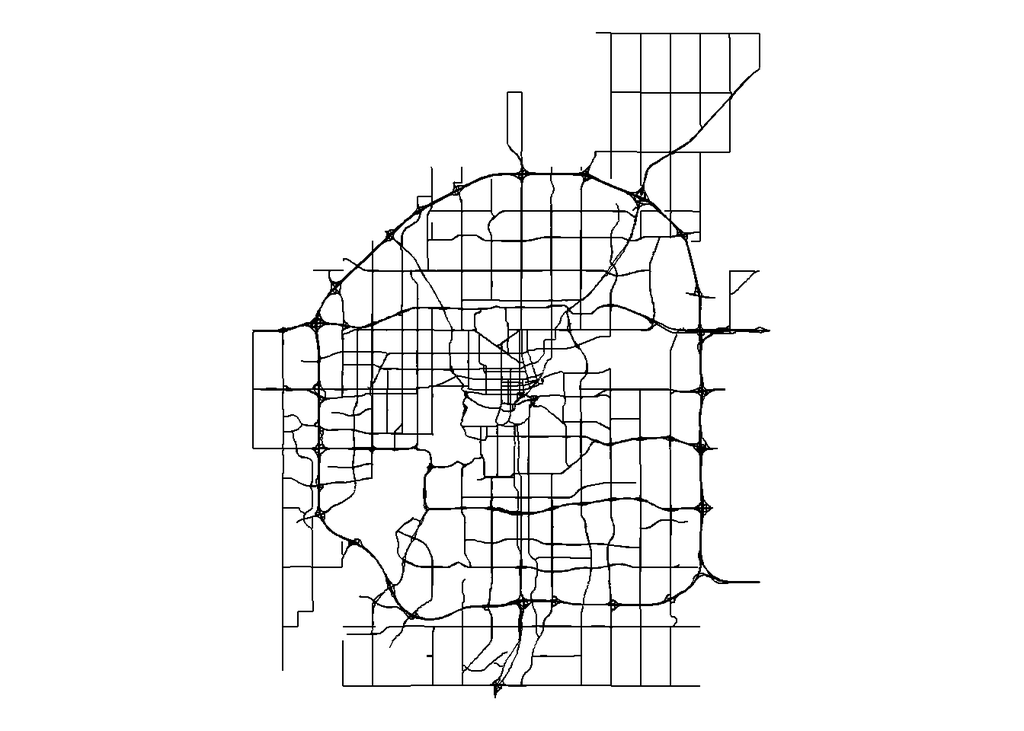

```r
edmonton_map <- ggplot(edmonton) +
  geom_sf() +
  theme_void()

edmonton_map
```

# Add a scale bar

The `ggspatial` package has a useful function called `annotation_scale()` that will add a scale bar to your map.

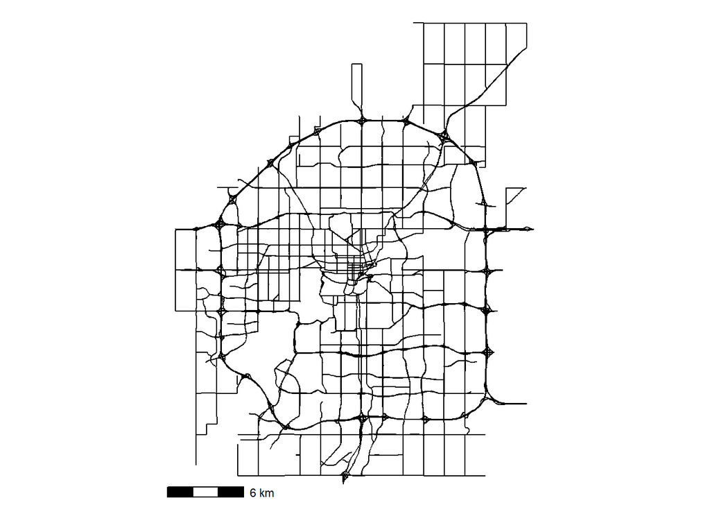

```r
edmonton_map +
  annotation_scale()
```

# Place the scale bar

By default, the scale bar is in the bottom left corner, but you can specify which corner of the map to place it using the `location` argument.

- `tr` means “top right”.
- `tl` means “top left”.
- `br` means “bottom right”.
- `bl` means “bottom left”

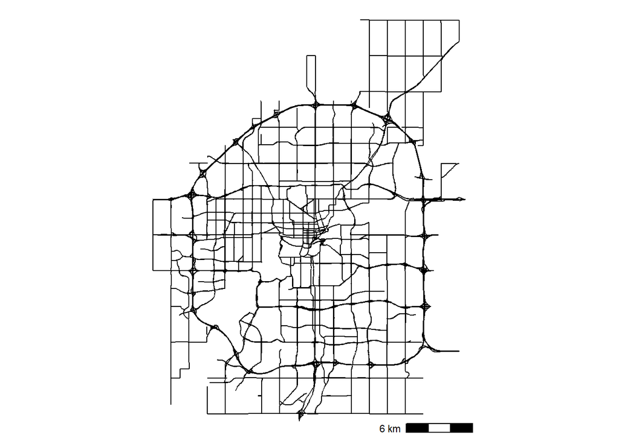

```r
edmonton_map +
  annotation_scale(location = "br")
```